# exercise manner prediction

cfir rahimi

December 27 2015

# Introduction

Using devices such as Jawbone Up, Nike FuelBand, and Fitbit it is now possible to collect a large amount of data about personal activity relatively inexpensively. These type of devices are part of the quantified self movement – a group of enthusiasts who take measurements about themselves regularly to improve their health, to find patterns in their behavior, or because they are tech geeks. In this research we will try to predict the exercise manner (“classe” field) by exploring the data with different models.

# Packages, Libraries and Seed

installing the relevent packages for the research, and set the seed for reproducibility.

```r
library(caret)
library(randomForest)
library(rpart)
library(rpart.plot)
library(rattle)
set.seed(1337)
```

# Data processing

first, we want to read the data and do small asjustments if needed.

```r
# read both files and replace NA Strings with NA.
training <- read.csv("pml-training.csv", na.strings=c("NA","#DIV/0!",""))
testing <- read.csv("pml-testing.csv", na.strings=c("NA","#DIV/0!",""))

# check the dimentions of the sets.
dim(training)
```

```
## [1] 19622   160
```

```r
dim(testing)
```

```
## [1]  20 160
```

```r
# ingnoring the first 7 columns which do not contain measurments.
training <- training[,-c(1:7)]
testing <- testing[,-c(1:7)]

# ignoring variables with very low variance.
nzv <- nearZeroVar(training, saveMetrics = TRUE)
training <- training[, !nzv$nzv]

# ignoring variables with more than 80% NA values.
nr <- nrow(training)
empty_variables <- sapply(colnames(training), function(x) if(sum(is.na(training[, x])) > 0.80*nr) {
  return(TRUE) } else { return(FALSE) })
training <- training[, !empty_variables]

# check the new dimentions of the data.
dim(training)
```

```
## [1] 19622    53
```

# Exploratory Data analysis

lets observe the data before we start the main analysis.

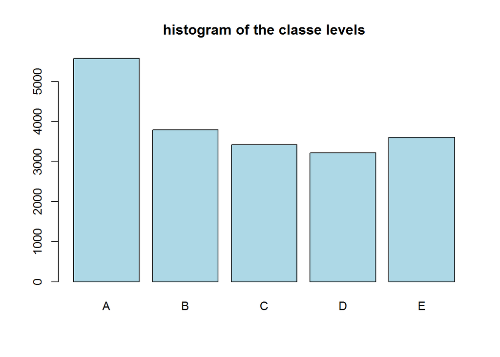

```r
plot(training$classe, main="histogram of the classe levels", col='light blue')
```

# main analysis

first we would like to make two partitions from the training set to enable cross-validation. I chose to split it so the training sebset contain 70% of the training set the testing subset contain 30% because it seems that in this way both bias and variance stay medium.

```r
partition <- createDataPartition(y=training$classe, p=0.7, list=FALSE)
subTraining <- training[partition, ]
subTesting <- training[-partition, ]
```

## first predicting model: Decision Tree

In the first attempt we are using a Decision tree model, which should be good for classification problems. the model:

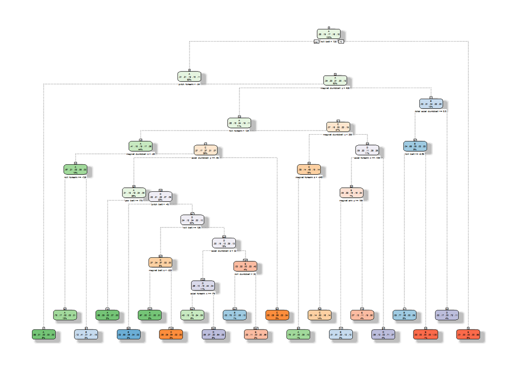

```r
fit_1 <- rpart(classe ~ ., data=subTraining, method="class")
fancyRpartPlot(fit_1, sub = "")
```

lets see how well it is predicting our test data:

```r
predictions_1 <- predict(fit_1, subTesting, type = "class")
c_1 <- confusionMatrix(predictions_1, subTesting$classe)
c_1
```

```
## Confusion Matrix and Statistics
##
##           Reference
## Prediction    A    B    C    D    E
##          A 1522  203   72  121   32
##          B   47  676   92   91   91
##          C   50  132  769  144  145
##          D   29   69   69  511   46
##          E   26   59   24   97  768
##
## Overall Statistics
##
##                Accuracy : 0.7215
##                  95% CI : (0.7098, 0.7329)
##     No Information Rate : 0.2845
##     P-Value [Acc > NIR] : < 2.2e-16
##
##                   Kappa : 0.6455
##  Mcnemar's Test P-Value : < 2.2e-16
##
## Statistics by Class:
##
##                      Class: A Class: B Class: C Class: D Class: E
## Sensitivity            0.9092   0.5935   0.7495  0.53008   0.7098
## Specificity            0.8984   0.9324   0.9031  0.95672   0.9571
## Pos Pred Value         0.7805   0.6780   0.6202  0.70580   0.7885
## Neg Pred Value         0.9614   0.9053   0.9447  0.91223   0.9361
## Prevalence             0.2845   0.1935   0.1743  0.16381   0.1839
## Detection Rate         0.2586   0.1149   0.1307  0.08683   0.1305
## Detection Prevalence   0.3314   0.1694   0.2107  0.12302   0.1655
## Balanced Accuracy      0.9038   0.7629   0.8263  0.74340   0.8335
```

we can see the accuracy = 0.7214953 , good results, but lets try the random forest model and comapre the results.

## second predicting model: Random Forests

```r
fit_2 <- randomForest(classe ~. , data=subTraining, ntree=100)
```

lets see how well it predicted our test data, we hope the results will be better:

```r
predictions_2 <- predict(fit_2, subTesting, type = "class")
c_2 <- confusionMatrix(predictions_2, subTesting$classe)
c_2
```

```
## Confusion Matrix and Statistics
##
##           Reference
## Prediction    A    B    C    D    E
##          A 1674    7    0    0    0
##          B    0 1128    8    0    0
##          C    0    4 1016    8    0
##          D    0    0    2  955    2
##          E    0    0    0    1 1080
##
## Overall Statistics
##
##                Accuracy : 0.9946
##                  95% CI : (0.9923, 0.9963)
##     No Information Rate : 0.2845
##     P-Value [Acc > NIR] : < 2.2e-16
##
##                   Kappa : 0.9931
##  Mcnemar's Test P-Value : NA
##
## Statistics by Class:
##
##                      Class: A Class: B Class: C Class: D Class: E
## Sensitivity            1.0000   0.9903   0.9903   0.9907   0.9982
## Specificity            0.9983   0.9983   0.9975   0.9992   0.9998
## Pos Pred Value         0.9958   0.9930   0.9883   0.9958   0.9991
## Neg Pred Value         1.0000   0.9977   0.9979   0.9982   0.9996
## Prevalence             0.2845   0.1935   0.1743   0.1638   0.1839
## Detection Rate         0.2845   0.1917   0.1726   0.1623   0.1835
## Detection Prevalence   0.2856   0.1930   0.1747   0.1630   0.1837
## Balanced Accuracy      0.9992   0.9943   0.9939   0.9949   0.9990
```

we got an amazing results, clearly the random forest model work much better, the accuracy here is: 0.9945624.

### final model plots

as we chose random forest as our final model we can see intresting plots on the model. the variance importance show us the main variable were chosen to split the data.

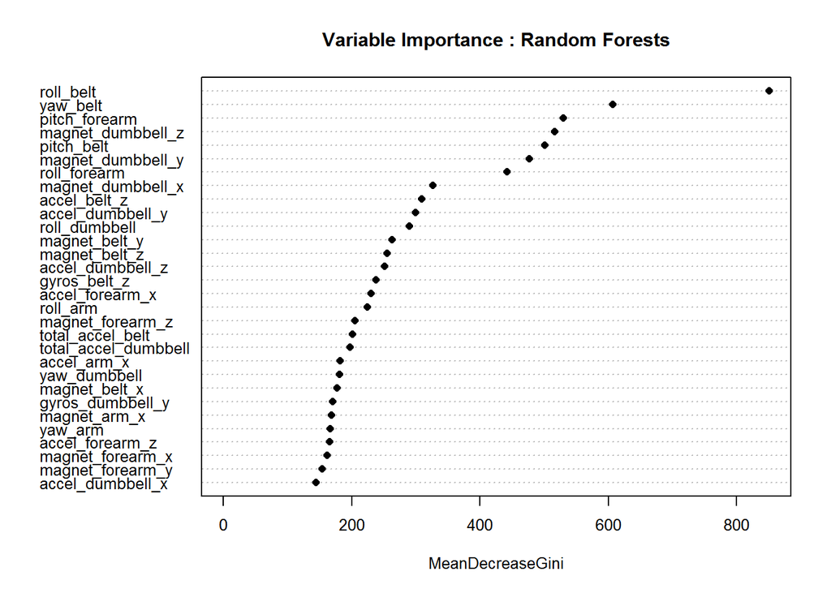

```r
varImpPlot(fit_2,main='Variable Importance : Random Forests',pch=16,col='black', cex = 0.8)
```

another interesting plot is to see how many trees needed to get the such amazing accuracy:

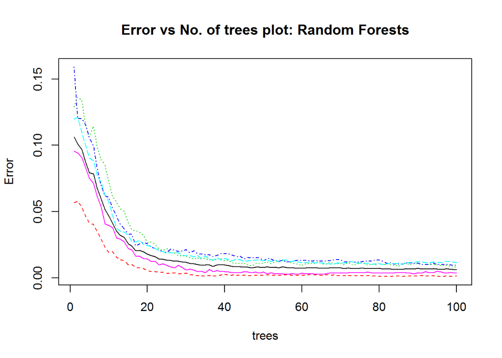

```r
plot(fit_2, main='Error vs No. of trees plot: Random Forests')
```

we can see from the plot the even 40 trees was enough.

# creating files for submission:

we need to run our model on the original test data:

```r
final_predictions <- predict(fit_2, testing, type = "class")
```

given function for creating the files on the final predictions:

```r
pml_write_files = function(x){
  n = length(x)
  for(i in 1:n){
    filename = paste0("problem_id_",i,".txt")
    write.table(x[i],file=filename,quote=FALSE,row.names=FALSE,col.names=FALSE)
  }
}

pml_write_files(final_predictions)
```

# conclusions

we tried two kind of models for predicting the classe variable, we got an amazing accuracy with the random forests model.